# Daten verarbeiten und vorbereiten

Dirk Seidensticker/Clemens Schmid

Februar 2016

## Daten verknüpfen (%in%, merge)

#### Daten verknüpfen - Idee

**Zusammenführen von Informationen aus verschiedenen Tabellen.**

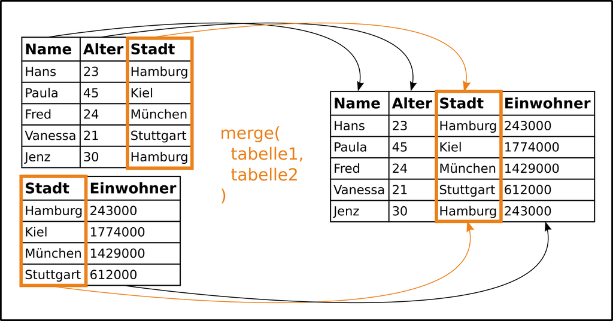

Vergleiche **Join-Operationen** in SQL (NATURAL JOIN, INNER JOIN, LEFT JOIN, RIGHT JOIN).

Am Anfang steht oft die Frage, ob gemeinsame Merkmalsausprägungen vorhanden sind: **%in%**

#### base::merge()

> merge(**x**, **y**, **by** = intersect(names(x), names(y)), **by.x** = by, **by.y** = by, **all** = FALSE, **all.x** = all, **all.y** = all, sort = TRUE, suffixes = c(“.x”,“.y”), incomparables = NULL, …)

**Beschreibung**

Merge two data frames by common columns or row names, or do other versions of database join operations.

**Beispiel**

```r
R <- data.frame(V1 = c(1,2,3), V2 = c(4,5,6), V3 = c("A","B","C"))
S <- data.frame(V4 = c(7,8,9), V5 = c(10,11,12), V6 = c("A","C","D"))

merge(x = R, y = S, by.x = "V3", by.y = "V6", all.x = TRUE)
```

```
##   V3 V1 V2 V4 V5
## 1  A  1  4  7 10
## 2  B  2  5 NA NA
## 3  C  3  6  8 11
```

#### base::match()

> match(**x**, **table**, **nomatch** = NA_integer_, incomparables = NULL)

> x **%in%** table

**Beschreibung**

match returns a vector of the positions of (first) matches of its first argument in its second.

%in% is a more intuitive interface as a binary operator, which returns a logical vector indicating if there is a match or not for its left operand.

**Beispiel**

```r
R <- data.frame(V1 = c(1,2,3), V2 = c(4,5,6), V3 = c("A","B","C"))
S <- data.frame(V4 = c(7,8,9), V5 = c(10,11,12), V6 = c("A","C","D"))

R$V3 %in% S$V6
```

```
## [1]  TRUE FALSE  TRUE
```

## Kategorisierung und Rangfolgen (factor & levels)

#### Kategorisierung und Rangfolgen - Idee

**Werte zu Klassen zusammen fassen und Klassen in eine Rangfolgen bringen**

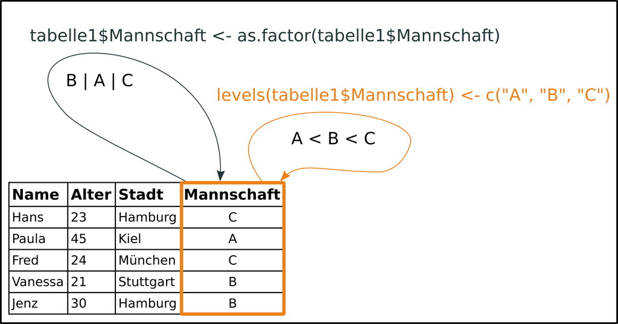

Klassifizierung und die Qualität von Klassen stecken nicht direkt in Daten - sie müssen klar zugewiesen werden.  
Insbesondere für Plots von Bedeutung.

#### base::factor()

> factor(**x** = character(), **levels**, **labels** = levels, exclude = NA, **ordered** = is.ordered(x), nmax = NA)

**Beschreibung**

The function factor is used to encode a vector as a factor (the terms ‘category’ and ‘enumerated type’ are also used for factors). If argument ordered is TRUE, the factor levels are assumed to be ordered.

**Beispiel**

```r
R <- data.frame(V1 = c(1.1,1.2,1.3), V2 = c(1,2,3))
R$V1 <- as.factor(x = R$V1)
R$V1
```

```
## [1] 1.1 1.2 1.3
## Levels: 1.1 1.2 1.3
```

#### base::levels()

> levels(**x**)

> levels(**x**) <- value

**Beschreibung**

levels provides access to the levels attribute of a variable. The first form returns the value of the levels of its argument and the second sets the attribute.

**Beispiel**

```r
R <- data.frame(V1 = c(1.1,1.2,1.3), V2 = c(1,2,3))
levels(x = R$V1) <- c(1.3,1.2,1.1)
R$V1
```

```
## [1] 1.1 1.2 1.3
## attr(,"levels")
## [1] 1.3 1.2 1.1
```

## Duplikate entfernen (unique & duplicated)

#### Duplikate entfernen - Idee

**Finden und Entfernen doppelter Werte und Wertekombinationen**

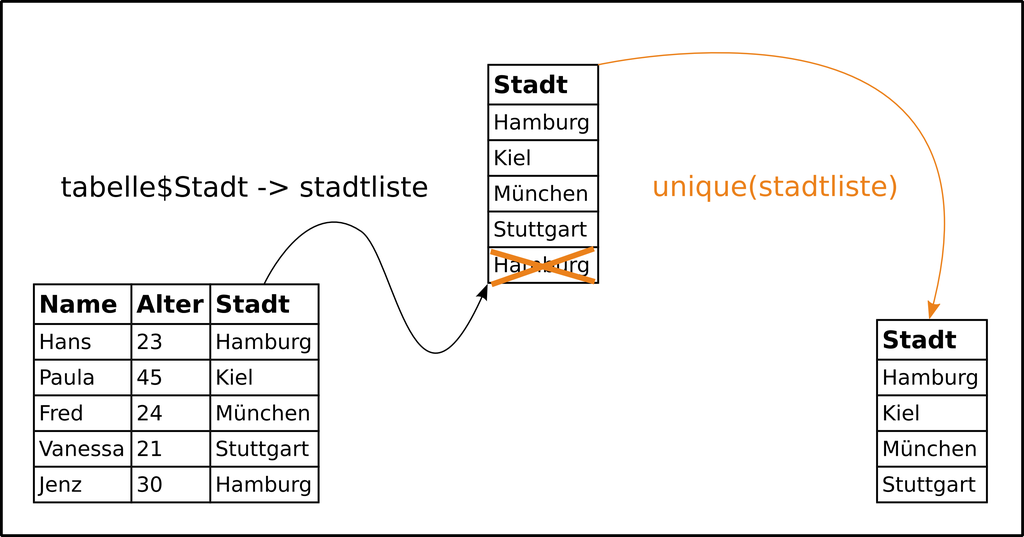

Duplikate entfernen und Bandbreite einer Merkmalsausprägung erfassen: “Was gibt es überhaupt?”

#### base::unique()

> unique(**x**, incomparables = FALSE, **fromLast** = FALSE, nmax = NA, …)

**Beschreibung**

unique returns a vector, data frame or array like x but with duplicate elements/rows removed.

**Beispiel**

```r
R <- data.frame(V1 = c(1,1,1), V2 = c(2,2,2), V3 = c("A","A","B"))
unique(x = R)
```

```
##   V1 V2 V3
## 1  1  2  A
## 3  1  2  B
```

#### base::duplicated()

> duplicated(**x**, incomparables = FALSE, **fromLast** = FALSE, nmax = NA, …)

**Beschreibung**

duplicated() determines which elements of a vector or data frame are duplicates of elements with smaller subscripts, and returns a logical vector indicating which elements (rows) are duplicates.

**Beispiel**

```r
R <- data.frame(V1 = c(1,1,1), V2 = c(2,2,2), V3 = c("A","A","B"))
duplicated(x = R, fromLast = TRUE)
```

```
## [1]  TRUE FALSE FALSE
```

```r
any(duplicated(R))
```

```
## [1] TRUE
```

## Sortieren (sort & order)

#### Sortieren - Idee

**Werte und Wertekombinationen in eine Reihenfolge bringen**

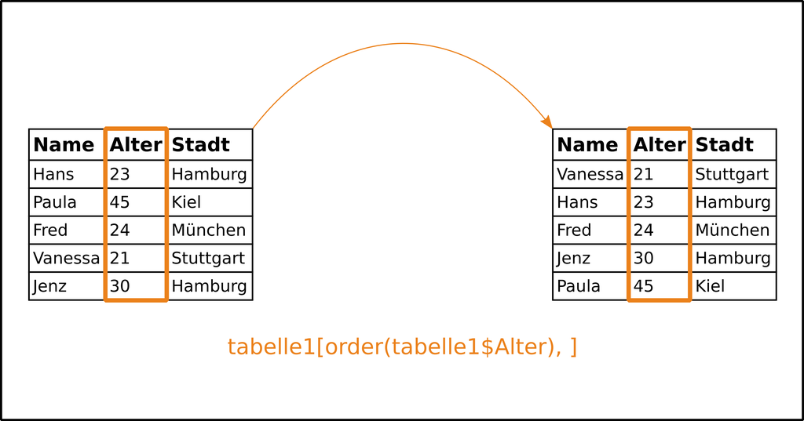

Sortieren läuft für verschiedene Datentypen unterschiedlich ab: Vgl. Zahlwerte, Worte, BLOBs, etc.

#### base::sort()

> sort(**x**, **decreasing** = FALSE, na.last = NA, …)

**Beschreibung**

Sort a vector or factor into ascending or descending order.

**Beispiel**

```r
V <- c("A","F","G","Käsebrot","B","X","Q")
sort(x = V, decreasing = TRUE)
```

```
## [1] "X"        "Q"        "Käsebrot" "G"        "F"        "B"
## [7] "A"
```

#### base::order()

> order(**…**, na.last = TRUE, **decreasing** = FALSE)

**Beschreibung**

order returns a permutation which rearranges its first argument into ascending or descending order, breaking ties by further arguments.

**Beispiel**

```r
R <- data.frame(V1 = c(1,1,1), V2 = c(132,78,5), V3 = c("B","A","A"))
order(R$V3, R$V2)
```

```
## [1] 3 2 1
```

```r
R[order(R$V3, R$V2), ]
```

```
##   V1  V2 V3
## 3  1   5  A
## 2  1  78  A
## 1  1 132  B
```

## Gruppieren und Gruppenoperationen (aggregate & group_by & summarise)

#### Gruppieren und Gruppenoperationen - Idee

**Gruppen bilden und gruppenbezogene Fragen stellen**

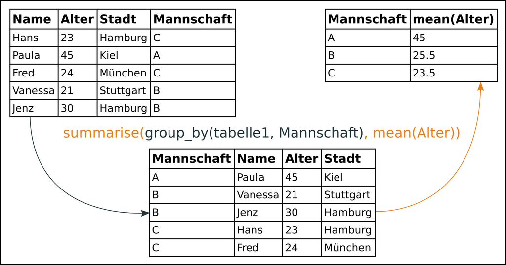

Gruppen werden immer in Abhängigkeit von Merkmalsausprägungen definiert.

Gruppenbezogene Fragen lassen nur gruppenbezogene Antworten zu - individuelle Werte gehen verloren.

#### stats::aggregate()

> aggregate(**x**, **by**, **FUN**, …, simplify = TRUE)

> aggregate(**formula**, **data**, **FUN**, …, subset, na.action = na.omit)

**Beschreibung**

Splits the data into subsets, computes summary statistics for each, and returns the result in a convenient form.

**Beispiel**

```r
R <- data.frame(V1 = c(3,5,1), V2 = c(3,8,5), V3 = c("B","A","A"))
aggregate(x = R, by = list(R$V3), FUN = "mean") -> a1
aggregate(V2~V3, data = R, FUN = "sum")
```

```
##   V3 V2
## 1  A 13
## 2  B  3
```

#### dplyr::group_by()

> group_by(**.data**, **…**, add = FALSE)

**Beschreibung**

The group_by function takes an existing tbl and converts it into a grouped tbl where operations are performed “by group”.

**Beispiel**

```r
R <- data.frame(V1 = c(3,5,1), V2 = c(3,8,5), V3 = c("B","A","A"))
group_by(R, V3)
```

```
## # A tibble: 3 x 3
## # Groups:   V3 [2]
##      V1    V2     V3
##   <dbl> <dbl> <fctr>
## 1     3     3      B
## 2     5     8      A
## 3     1     5      A
```

#### dplyr::summarise()

> summarise(**.data**, **…**)

**Beschreibung**

Summarise multiple values to a single value.

**Beispiel**

```r
R <- data.frame(V1 = c(4,5,1), V2 = c(3,8,5), V3 = c("B","A","A"))
R.g <- group_by(R, V3)
summarise(R.g, Mittwelwert = mean(V1), Summe = sum(V2))
```

```
## # A tibble: 2 x 3
##       V3 Mittwelwert Summe
##   <fctr>       <dbl> <dbl>
## 1      A           3    13
## 2      B           4     3
```

## Pivotieren (*apply & dcast)

#### Pivotieren

```r
atlant <- read.csv(
  "downloads/r-tut/data/AtlantData1.csv",
  sep = "\t",
  header = TRUE
  )
```

#### Kreuztabelle mit Auszählen

```r
table(atlant$site, atlant$size)
```

```
##
##     30 70 120 200 500
##   A  0  0   1   2   5
##   B  0  0   0   2   2
##   C  0  1   2   0   1
##   D  0  8   7   1   0
##   E  0  0   0   2   2
##   F  1 12  20  23   9
##   G  0  0   1   2   2
##   H  0 15   8   5   0
```

#### Kreuztabelle mit Auszählen

*dito mit tapply*

```r
a <- tapply(atlant$qty, list(atlant$site, atlant$size), length)
a[is.na(a)] <- 0
a
```

```
##   30 70 120 200 500
## A  0  0   1   2   5
## B  0  0   0   2   2
## C  0  1   2   0   1
## D  0  8   7   1   0
## E  0  0   0   2   2
## F  1 12  20  23   9
## G  0  0   1   2   2
## H  0 15   8   5   0
```

#### Berechnungen in Abhängigkeit zu einer Variable

```r
tapply(atlant$wt, list(atlant$site), sum)
```

```
##     A     B     C     D     E     F     G     H
##  8805  6621  1641  1760  4825 22849  3525  4530
```

#### Berechnungen in Abhängigkeit zu einer Variable

```r
data.frame(tapply(atlant$wt, list(atlant$site), sum))
```

```
##   tapply.atlant.wt..list.atlant.site...sum.
## A                                      8805
## B                                      6621
## C                                      1641
## D                                      1760
## E                                      4825
## F                                     22849
## G                                      3525
## H                                      4530
```

#### Berechnungen in Abhängigkeit zu einer Variable

```r
data.frame(tapply(atlant$wt, list(atlant$site),
                  function(x){sum(x)/1000}))
```

```
##   tapply.atlant.wt..list.atlant.site...function.x...
## A                                              8.805
## B                                              6.621
## C                                              1.641
## D                                              1.760
## E                                              4.825
## F                                             22.849
## G                                              3.525
## H                                              4.530
```

#### Berechnungen in Abhängigkeit zu zwei Variablen

```r
b <- data.frame(tapply(atlant$wt,
                list(atlant$site, atlant$size), sum),
                check.names = FALSE)
b[is.na(b)] <- 0
b
```

```
##   30  70  120  200   500
## A  0   0   67 1536  7202
## B  0   0    0 1003  5618
## C  0  45  148    0  1448
## D  0 272 1150  338     0
## E  0   0    0 1481  3344
## F  6 453 2015 9812 10563
## G  0   0   84 1002  2439
## H  0 512 1007 2921     0
```

#### Auszählen in Abhängigkeit zu drei Variablen

```r
library(reshape2)

pivot <- dcast(atlant, site + feature ~ size)
head(pivot)
```

```
##   site feature 30 70 120 200 500 NA
## 1    A       1  0  0   1   1   4  0
## 2    A surface  0  0   0   1   1  0
## 3    B surface  0  0   0   2   2  0
## 4    C surface  0  1   2   0   1  0
## 5    D       1  0  6   4   1   0  0
## 6    D       2  0  1   1   0   0  0
```

#### Berechnungen in Abhängigkeit zu drei Variablen

```r
pivot2 <- dcast(atlant, site + feature ~ size,
      value.var = "wt",
      fun.aggregate = sum)

head(pivot2)
```

```
##   site feature 30  70 120  200  500 NA
## 1    A       1  0   0  67 1012 5630  0
## 2    A surface  0   0   0  524 1572  0
## 3    B surface  0   0   0 1003 5618  0
## 4    C surface  0  45 148    0 1448  0
## 5    D       1  0 159 749  338    0  0
## 6    D       2  0  74 167    0    0  0
```

## Datenanordnung - wide to long und long to wide (melt)

#### Melt

> Eingabeformat für ggplot2()!!!

Wir wollen diese vorhin erstelle Tabelle plotten:

```r
a
```

```
##   30 70 120 200 500
## A  0  0   1   2   5
## B  0  0   0   2   2
## C  0  1   2   0   1
## D  0  8   7   1   0
## E  0  0   0   2   2
## F  1 12  20  23   9
## G  0  0   1   2   2
## H  0 15   8   5   0
```

#### Melt

```r
library(reshape2)
atlant_sites.size <- melt(a)

head(atlant_sites.size)
```

```
##   Var1 Var2 value
## 1    A   30     0
## 2    B   30     0
## 3    C   30     0
## 4    D   30     0
## 5    E   30     0
## 6    F   30     1
```

#### Melt

```r
colnames(atlant_sites.size) <- c('site', 'size', 'qty')

head(atlant_sites.size)
```

```
##   site size qty
## 1    A   30   0
## 2    B   30   0
## 3    C   30   0
## 4    D   30   0
## 5    E   30   0
## 6    F   30   1
```

## Filtern (subset & filter)

#### Filter und Subseting nach site ‘F’

```r
atlant_sub <- subset(atlant, site == 'F')
head(atlant_sub)
```

```
##    site      X       Y    archont feature                 object class
## 37    F 458694 3951533 Autochthon       2                   -8:1     K
## 38    F 458694 3951533 Autochthon       1                   -3:1     K
## 39    F 458694 3951533 Autochthon       1                   -6:2     K
## 40    F 458694 3951533 Autochthon       2     -2:2 -4:3,10-11,13     K
## 41    F 458694 3951533 Autochthon       2                   -4:2     K
## 42    F 458694 3951533 Autochthon       2 -4:5-6,8,12,14-21 -5:3     K
##    sherd qty  wt size wall muendungsD muendungsH minD minD_H maxD maxD_H
## 37     G   1 829  500    7       20.5       12.5 17.5    8.5 19.0    4.0
## 38     G   1 155  120    4       11.5        6.5 12.0    5.0  5.0    2.5
## 39     G   1 504  200    4        5.0       18.5  6.5   14.0 16.5    7.5
## 40     G   1 419  200   10       19.0       14.0 17.0   10.0 17.5    3.0
## 41     G   1 691  500   10       20.0       12.0 17.5    9.0 18.0    5.0
## 42     G   1 623  500   10       18.5       13.0 17.0   11.0 18.0    5.0
##    bodenD temperSize vesselShape
## 37    0.0         VF         S1b
## 38    5.0          F         S2g
## 39    6.5         VF        S11b
## 40    0.0          F         S1a
## 41    0.0         VF         S1a
## 42    0.0         VF         S1b
```

#### Filter mit mehrere Bedingungen

```r
library(dplyr)
```

```r
atlant_filter <- filter(atlant, site == 'F' & wall > 5)
head(atlant_filter)
```

```
##   site      X       Y    archont feature                 object class
## 1    F 458694 3951533 Autochthon       2                   -8:1     K
## 2    F 458694 3951533 Autochthon       2     -2:2 -4:3,10-11,13     K
## 3    F 458694 3951533 Autochthon       2                   -4:2     K
## 4    F 458694 3951533 Autochthon       2 -4:5-6,8,12,14-21 -5:3     K
## 5    F 458694 3951533 Autochthon       2    -4:4,7,9 -5:4-6,8-9     K
## 6    F 458694 3951533 Autochthon       2                   -5:2     K
##   sherd qty   wt size wall muendungsD muendungsH minD minD_H maxD maxD_H
## 1     G   1  829  500    7       20.5       12.5 17.5    8.5 19.0    4.0
## 2     G   1  419  200   10       19.0       14.0 17.0   10.0 17.5    3.0
## 3     G   1  691  500   10       20.0       12.0 17.5    9.0 18.0    5.0
## 4     G   1  623  500   10       18.5       13.0 17.0   11.0 18.0    5.0
## 5     G   1  344  200   10         NA         NA 18.0    8.5 17.5    2.0
## 6     G   1 1671  500   12       24.5       15.0 21.5   10.5 22.5    3.5
##   bodenD temperSize vesselShape
## 1      0         VF         S1b
## 2      0          F         S1a
## 3      0         VF         S1a
## 4      0         VF         S1b
## 5      0         VF         S1b
## 6      0         VF         S1a
```